# 6 Months Catch Data Report - WCS BAF

Author

Affiliation

Kaijage Laurian

Mwambao Coastal Communnity Network

Published

August 9, 2025

Modified

August 12, 2025

# 1 INTRODUCTION

Artisanal fisheries are a key livelihood for coastal communities in Tanzania. However, in recent years, these fisheries have experienced a decline due to various factors such as climate change, over-exploitation, invasive species, pollution, natural calamities, and habitat degradation. These communities rely heavily on nearby natural resources, particularly mangrove forests and coral reefs. Without proper regulation and management, these vital ecosystems may no longer be able to support the people who depend on them.

To address this, the Mwambao Coastal Community Network has been working in collaboration with coastal communities, to promote the sustainable use of marine resources. One of the primary tools employed is participatory management planning, which empowers communities to identify and implement suitable measures for their local marine areas. In the context of coral reef management, proposed interventions have included temporal reef closures to enhance octopus catches, permanent no-take zones (also known as community-managed fisheries replenishment zones), and, less commonly, gear restrictions.

To ensure that management decisions are data-driven and well-informed, catch data collection has been prioritized. This includes data on both reef fish and octopus, gathered using the Mwambao methodology and stored in the Mwambao ArcGIS database. Since the first training on fish catch monitoring held on September, data collection has been ongoing in 3 communities with support from BAF funding.

This report presents the catch data collected, its analysis and interpretation, the challenges encountered during the process, and key recommendations to support effective community-based fisheries management.

# 2 MATERIAL AND METHODS

## 2.1 Sites

Data were collected from three villages, Tumbe, Shumba, and Kiuyu each with a single monitored landing site. Fishing activities from these sites covered 45 fishing grounds, as illustrated in Figure 1.

[interactive chart not shown]

## 2.2 Data collection

Data collection was carried out three days per week (equivalent to approximately 12 days per month) by trained community data recorders stationed at designated landing sites. Each recorder was tasked with documenting landings from up to 10 fishers per day using standardized logbooks.

To ensure data accuracy and consistency, logbook entries were transcribed into the Survey123 digital form by data entry personnel. Importantly, data were not submitted until the entries were verified by regional data officers, particularly with respect to location information. This verification step was implemented to minimize errors and ensure clean, reliable datasets.

To support accurate species identification, a [Fish ID guidebook](https://drive.google.com/file/d/1C4HvZUALSHoXRJoa4eJ6_tr2a3nlM59n/view?usp=drive_link) was distributed to all sites and used as a reference tool by recorders during data collection.

All collected data were stored in ArcGIS Online, from where they were downloaded and imported into R for cleaning, processing, and statistical analysis

### 2.2.1 Data checking

1. Monthly Data Checks Designated data officers from North Pemba conduct routine monthly visits to all participating villages. During these visits, the officer validate that the information recorded in the physical logbooks aligns with entries in the digital Survey123 forms. Any discrepancies identified are resolved before the data is officially submitted. In addition to data validation, officers also verify the number of active working days for each recorder, which is essential for processing performance-based payments. These verification results are logged using a dedicated KoBoToolbox digital form.
2. Unannounced Spot Checks To further ensure data quality and adherence to protocols, data officer carry out random, unannounced spot checks each month. These visits confirm that data recorders are present at the designated locations and are following the proper data collection procedures. Any absence or failure to comply with protocols results in a verbal warning, followed by a written warning for repeat offenses. This process is intended to safeguard the credibility of the data.
3. Capacity Building and Follow-up Training To strengthen the capacity of data recorders and reduce errors, follow-up training is conducted approximately three months after initial deployment. These sessions focus on improving fish identification skills, reviewing previously collected data, and reinforcing correct data entry methods. This continuous learning approach helps enhance the overall quality and consistency of the data.

# 3 RESULTS

## 3.1 CPUE Trends

From these results, Tumbe recorded a mean catch of 3864.7 g, Shumba 3299.8 g, and Kiuyu 3243.8 g.

In Tumbe, the average catch weight ranged from 36 g to 9950 g, while CPUE varied between 9.25 g/fisher/day and 4800 g/fisher/day.

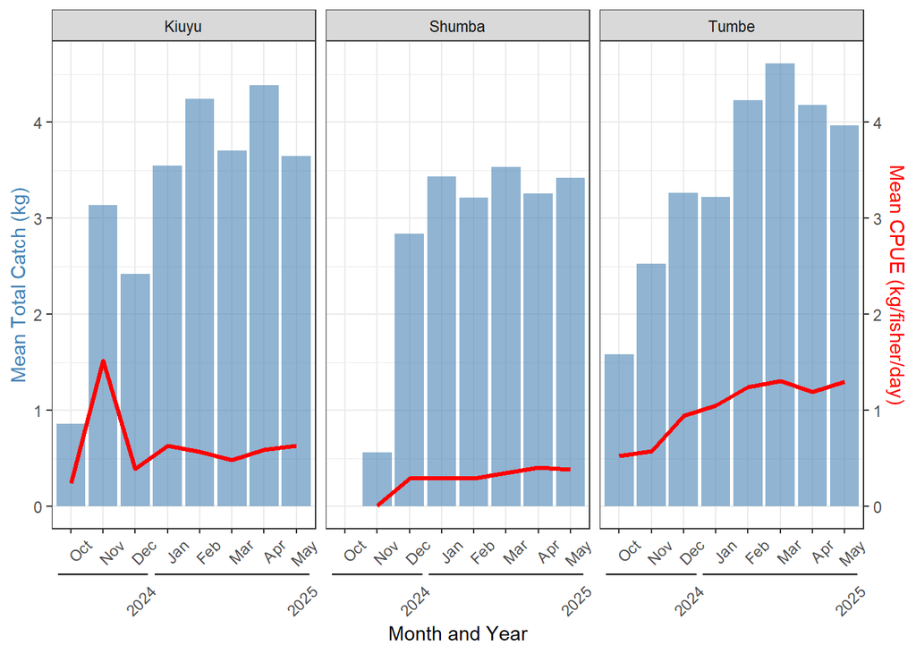

Figure 2: temporal trends in mean total catch (blue bars) and mean catch per unit effort (CPUE, red line).

## 3.2 Selected Family Trends

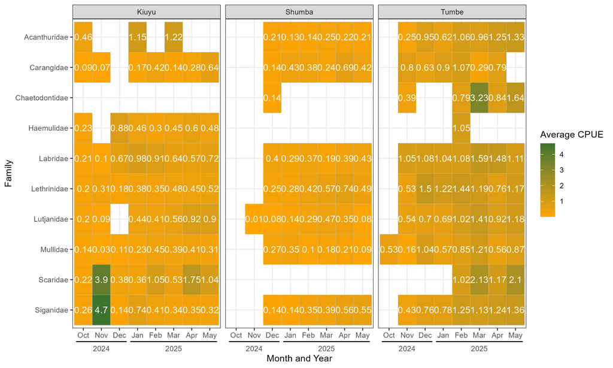

Figure 3: Change in abundance and availability of 10 selected reef fish families

## 3.3 Fishing Grounds Use and CPUE

Table 1: The fishing ground CPUE from Kiuyu, Tumbe and Shumba calculated as g/fisher/day

| Fishing Grounds | Kiuyu | Tumbe | Shumba |
| --- | --- | --- | --- |
| Kongoo majini | 2,705.15 |  |  |
| Kiweni |  | 1,711.67 |  |
| Pwakuu | 1,558.19 |  |  |
| Kitwani |  | 1,472.49 |  |
| Farumuni |  | 1,331.39 | 161.40 |
| Jambani | 646.18 | 1,248.77 | 248.39 |
| Kongoo ya kati |  | 1,244.38 |  |
| Funguni |  | 1,211.84 |  |
| Jamba nungwi |  | 1,196.40 |  |
| Kisiwani |  | 1,182.59 |  |
| Magambare |  | 1,142.86 |  |
| Kundeni |  | 1,029.78 | 96.71 |
| Kumwilikiza |  |  | 991.67 |
| Mnarani |  | 956.78 | 222.32 |
| Ngalawa | 955.00 |  |  |
| Rasini |  | 886.29 |  |
| Imu | 21.64 | 792.41 | 876.48 |
| Mapakacha | 624.98 |  | 874.79 |
| Majimbuni | 870.91 |  |  |
| Kongoo | 674.99 | 707.96 | 801.07 |
| Jiwe mtu |  |  | 793.50 |
| Pwavile |  | 728.63 |  |
| Ng'ande | 645.77 |  |  |
| Kagera |  |  | 632.77 |
| Kongoo mchele | 624.45 |  |  |
| Mchichani |  | 619.38 |  |
| Jiweni |  |  | 601.25 |
| Kekechu | 590.69 |  |  |
| Jiwemtu |  |  | 552.08 |
| Mwamba wa pili | 545.00 |  |  |
| Pwachi | 504.47 |  |  |
| Mdomoni | 490.50 |  |  |
| Mwamba wa kwanza | 489.05 |  |  |
| Kudeni |  | 485.16 |  |
| Kijiweni | 450.84 |  |  |
| Kongoo ya kiuyu |  |  | 407.25 |
| Shangaa | 381.12 |  |  |
| Changa fusini |  |  | 340.45 |
| Mwamba wa tatu | 277.30 |  |  |
| Uziwani |  | 180.98 | 273.69 |
| Mwambani |  |  | 261.59 |
| Uzini |  | 216.00 |  |
|  | 105.30 |  |  |
| Matoma | 97.25 |  |  |

## 3.4 Gear use

Table 2: The Frequency of gear used during the data collection period

| Gear | Kiuyu | Tumbe | Shumba |
| --- | --- | --- | --- |
| Gillnet | 648 |  |  |
| Fish_trap |  | 512 |  |
| Handline | 21 | 278 | 193 |
| Other |  |  | 239 |
| Speargun | 181 |  |  |
| Seinnet |  | 37 | 125 |
| Diving | 37 |  |  |
| Purse_seines/ring_nets |  |  | 16 |
| Gillnet,Monofilament_net | 1 |  |  |
| Gillnet,Speargun | 1 |  |  |
| Monofilament_net | 1 |  |  |
| Speargun,Gillnet | 1 |  |  |
| Handline,Fish_trap |  |  | 1 |

Table 3: The recorded CPUE in g/fisher/day for each gear recorded

| Gear | Tumbe | Kiuyu | Shumba |
| --- | --- | --- | --- |
| Seinnet | 1,248.16 |  | 106.58 |
| Fish_trap | 1,051.55 |  |  |
| Handline | 997.81 | 429.10 | 653.26 |
| Speargun |  | 807.84 |  |
| Gillnet,Monofilament_net |  | 744.17 |  |
| Handline,Fish_trap |  |  | 633.57 |
| Monofilament_net |  | 379.17 |  |
| Gillnet |  | 304.90 |  |
| Speargun,Gillnet |  | 235.20 |  |
| Gillnet,Speargun |  | 230.83 |  |
| Diving |  | 192.84 |  |
| Other |  |  | 112.31 |
| Purse_seines/ring_nets |  |  | 86.09 |

## 3.5 Vessel use

Table 4

| Vessel used | Kiuyu | Tumbe | Shumba |
| --- | --- | --- | --- |
| Canoe | 808 | 566 | 108 |
| Boat_ engine | 29 |  | 303 |
| Fiber | 16 | 256 | 160 |
| Sail _boat | 17 |  | 1 |
| Walk | 7 |  |  |
| Ngwanda | 6 |  |  |
| skin_diving | 5 |  |  |
| Scuba_diving |  |  | 1 |

## 3.6 Data Checking

A number of issues have arisen from the data checking process. In some instances, recorders were found to be entering catch data for future dates in advance, likely to save time. There were also cases where only one recorder was present at the landing site, leading to incomplete coverage. Methodological errors were observed, including misidentification of fish species despite the availability of fish ID guides, and deviations from the approved data collection protocols. Additional issues included incomplete data entries, such as blanks left during logging, and discrepancies between information recorded in logbooks and that entered into the digital forms. In some cases, data were logged only in physical logbooks and not in the digital system, or vice versa. These challenges highlight the importance of ongoing capacity building, regular supervision, and systematic data audits to ensure data quality and integrity. For more detail please read [data checking reports](https://docs.google.com/document/d/1OVOnjDSMJV-7NXhmfnCUBr8AayRoAiIx/edit?usp=drive_link&ouid=117181916031444492229&rtpof=true&sd=true).

# 4 DISCUSION

The overlap in fishing ground use (e.g., Jambani, Kundeni, Mnarani, Imu, Mapakacha) highlights potential hotspots of fishing pressure. Without coordinated management, such shared sites are at higher risk of overexploitation. Gear-specific CPUE patterns, with seine nets (1,248 g/fisher/day) and fish traps (1,052 g/fisher/day) producing the highest returns — indicate that these gears may disproportionately impact target species and habitats if used intensively.

# 5 RECOMMENDATION

Given these patterns, a mixed management strategy is recommended:

Permanent Closures – Designate no-take zones around critical and shared fishing grounds such as Jambani and Kundeni. Permanent closures in these areas could function as spillover sources to replenish surrounding reefs.

Gear Restrictions – Regulate high-impact gears such as seine nets, especially in sensitive habitats, and limit the number of traps to reduce habitat damage .